# DataCamp - Introduction to Data Visualization with ggplot2

Andrex Ibiza, MBA

2025-01-29

# Chapter 1: Introduction

In this chapter we’ll get you into the right frame of mind for developing meaningful visualizations with R. You’ll understand that as a communications tool, visualizations require you to think about your audience first. You’ll also be introduced to the basics of ggplot2 - the 7 different grammatical elements (layers) and aesthetic mappings.

## Video 1.1: Introduction to ggplot2

This is an introduction to data visualization with ggplot2. We will cover the basics of ggplot2 and how to create different types of plots using ggplot2.

### A scatter plot

```r
mammals <- MASS::mammals
```

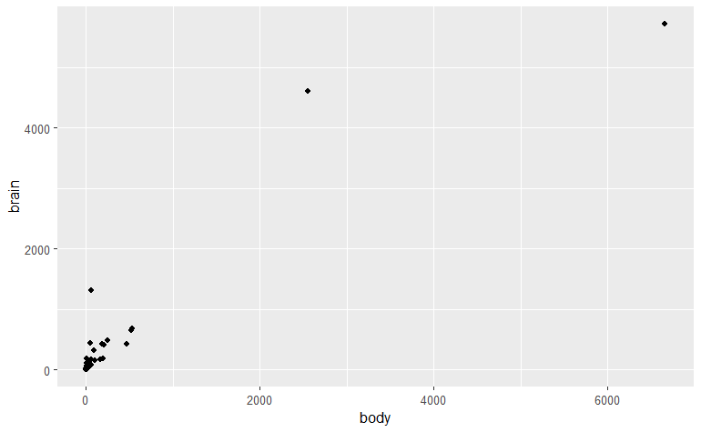

```r
library(ggplot2)
ggplot(mammals, aes(x = body, y = brain)) +
  geom_point()
```

### Explore with a linear model

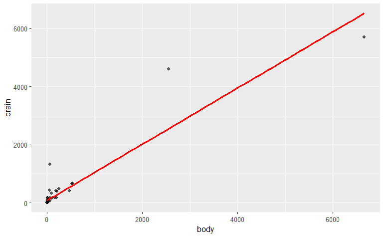

```r
ggplot(mammals, aes(x = body, y = brain)) +
  geom_point(alpha = 0.6) +
  stat_smooth(
    method = "lm",
    color = "red",
    se = FALSE
  )
```

### Explore: fine-tuning

```r
ggplot(mammals, aes(x = body, y = brain)) +
  geom_point(alpha = 0.6) +
  coord_fixed() +
  scale_x_log10() +
  scale_y_log10() +
  stat_smooth(
    method = "lm",
    color = "#C42126",
    se = FALSE,
    size = 1
  )
```

[output not shown]

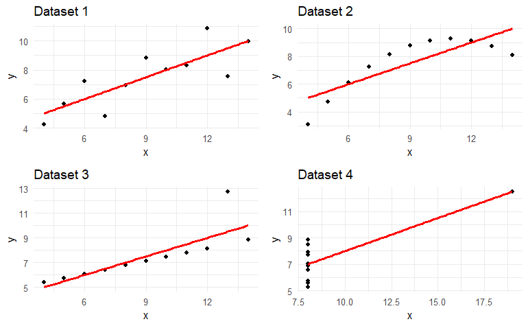

```r
# Load necessary libraries
library(ggplot2)
library(gridExtra)

# Load Anscombe's Quartet data
data(anscombe)

# Create a list of data frames for each dataset in the quartet
anscombe_list <- list(
  data.frame(x = anscombe$x1, y = anscombe$y1, group = "Dataset 1"),
  data.frame(x = anscombe$x2, y = anscombe$y2, group = "Dataset 2"),
  data.frame(x = anscombe$x3, y = anscombe$y3, group = "Dataset 3"),
  data.frame(x = anscombe$x4, y = anscombe$y4, group = "Dataset 4")
)

# Create a function to generate a plot for each dataset
plot_anscombe <- function(data) {
  ggplot(data, aes(x = x, y = y)) +
    geom_point() +
    geom_smooth(method = "lm", se = FALSE, color = "red") +
    labs(title = data$group[1]) +
    theme_minimal()
}

# Generate plots for each dataset
plots <- lapply(anscombe_list, plot_anscombe)

# Arrange the plots in a 2x2 grid
grid.arrange(grobs = plots, ncol = 2)
```

## Video 1.2: The grammar of graphics

Course 1: core competencies

| Element | Description |
| --- | --- |
| Data | The data-set being plotted. |
| Aesthetics | The scales onto which we map our data. |
| Geometries | The visual elements used for our data. |
| Themes | All non-data ink. |

Course 2: Tools for EDA * remaining 3 layers * best practices for data viz

### The seven grammatical elements of ggplot2

| Element | Description |
| --- | --- |
| Data | The data-set being plotted. |
| Aesthetics | The scales onto which we map our data. |
| Geometries | The visual elements used for our data. |
| Themes | All non-data ink. |
| Statistics | Representations of our data to aid understanding. |
| Coordinates | The space on which the data will be plotted. |
| Facets | Plotting small multiples. |

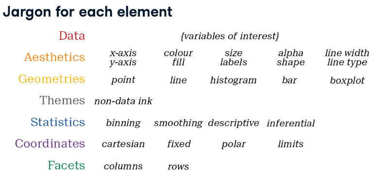

## Video 1.3: ggplot2 layers

- Two key concepts:
  1. layer grammatical elements
  2. aesthetic mappings

```r
iris
```

| Sepal.Length | Sepal.Width | Petal.Length | Petal.Width | Species |
| --- | --- | --- | --- | --- |
| 5.1 | 3.5 | 1.4 | 0.2 | setosa |
| 4.9 | 3.0 | 1.4 | 0.2 | setosa |
| 4.7 | 3.2 | 1.3 | 0.2 | setosa |
| 4.6 | 3.1 | 1.5 | 0.2 | setosa |
| 5.0 | 3.6 | 1.4 | 0.2 | setosa |
| 5.4 | 3.9 | 1.7 | 0.4 | setosa |
| 4.6 | 3.4 | 1.4 | 0.3 | setosa |
| 5.0 | 3.4 | 1.5 | 0.2 | setosa |
| 4.4 | 2.9 | 1.4 | 0.2 | setosa |
| 4.9 | 3.1 | 1.5 | 0.1 | setosa |

[output cut: 140 more lines]

### Iris geometries

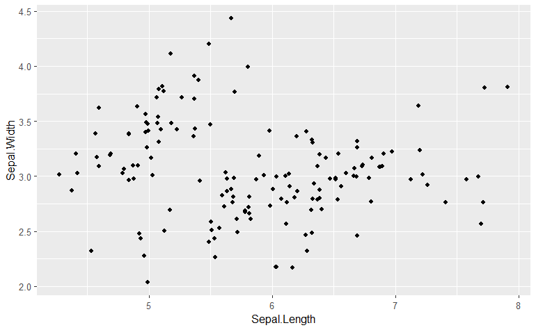

```r
g <- ggplot(iris, aes(x = Sepal.Length, y = Sepal.Width)) +
  geom_jitter()
g
```

### Iris themes

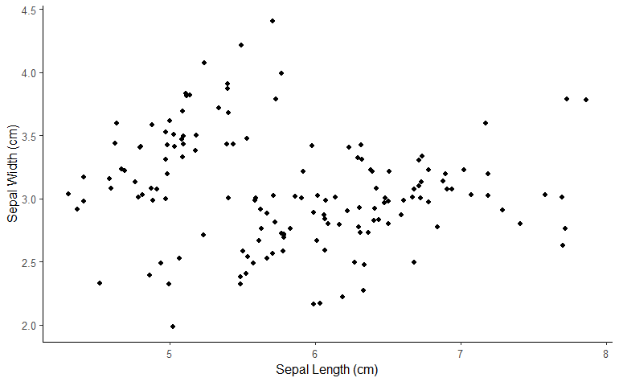

```r
g <- g +
  labs(x = "Sepal Length (cm)", y = ("Sepal Width (cm)")) +
  theme_classic()
g
```

# Chapter 2: Aesthetics

Aesthetic mappings are the cornerstone of the grammar of graphics plotting concept. This is where the magic happens - converting continuous and categorical data into visual scales that provide access to a large amount of information in a very short time. In this chapter you’ll understand how to choose the best aesthetic mappings for your data.

## Video 2.1: Visible Aesthetics

### Mapping onto the X and Y axes

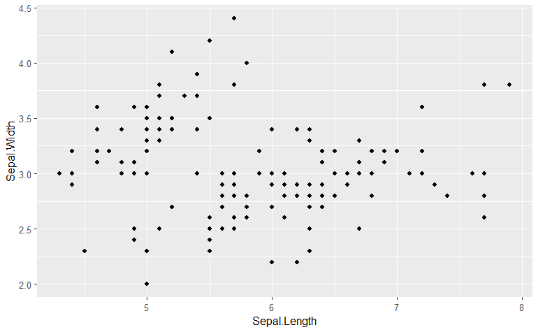

```r
ggplot(iris, aes(x = Sepal.Length, y = Sepal.Width)) +
  geom_point()
```

### Mapping onto color

```r
ggplot(iris, aes(x = Sepal.Length, y = Sepal.Width, color = Species)) +
  geom_point()
```

- `Species`, a dataframe column, is *mapped* onto color, a visible aesthetic.
- Map aesthetics visible in `aes()`.

### Mapping onto the color aesthetic in geom

```r
ggplot(iris) +
  geom_point(aes(x = Sepal.Length, y = Sepal.Width, col = Species))
```

Only necessary if: * All layers should *not* inherit the same aesthetics. * Mixing different data sources.

### Typical visible aesthetics:

| Aesthetic | Description |
| --- | --- |
| `x` | X axis position |
| `y` | Y axis position |
| `fill` | Fill color |
| `color` | color of points, outlines of other geoms |
| `size` | Area or radius of points, thickness of lines |
| `alpha` | transparency |
| `linetype` | line dash pattern |
| `labels` | text on a plot or axes |
| `shape` | shape |

## Video 2.2: Using Attributes

### Aesthetics? Attributes!

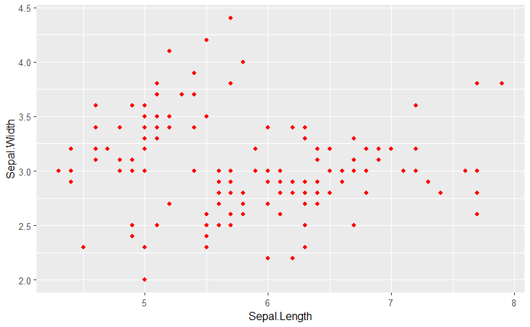

```r
ggplot(iris, aes(x = Sepal.Length,
                 y = Sepal.Width,
                 )) +
  geom_point(color = "red")
```

- Set attributes in `geom_*()` functions.
- The **color** attribute is set to **“red”**.

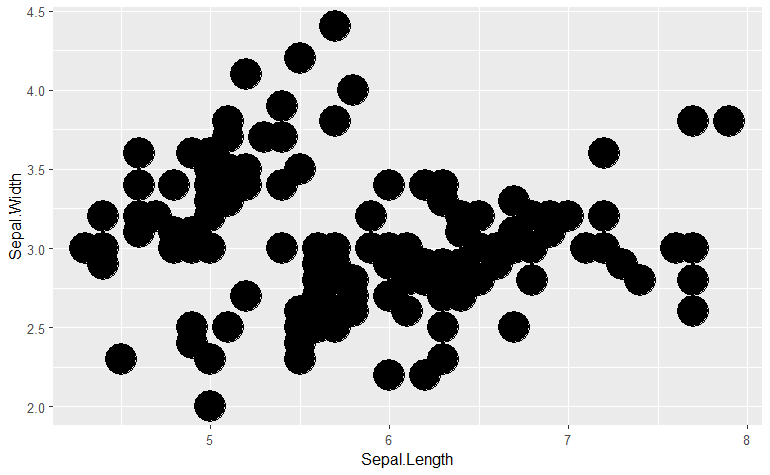

```r
ggplot(iris, aes(x = Sepal.Length,
                 y = Sepal.Width,
                 )) +
  geom_point(size = 10)
```

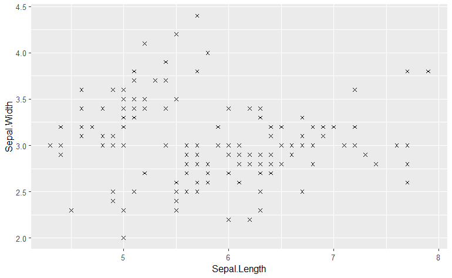

```r
ggplot(iris, aes(x = Sepal.Length,
                 y = Sepal.Width,
                 )) +
  geom_point(shape = 4)
```

## Video 2.3: Modifying Aesthetics

### Positions

Adjustment for overlapping points: - `identity` - `dodge` - `stack` - `fill` - `jitter` - `jitterdodge` - `nudge`

### position = “identity” (default)

```r
ggplot(iris, aes(x = Sepal.Length,
                 y = Sepal.Width,
                 color = Species)) +
  geom_point()
```

```r
ggplot(iris, aes(x = Sepal.Length,
                 y = Sepal.Width,
                 color = Species)) +
  geom_point(position = "identity")
```

### position = “jitter”

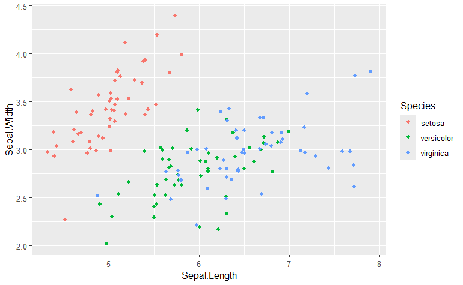

```r
ggplot(iris, aes(x = Sepal.Length,
                 y = Sepal.Width,
                 color = Species)) +
  geom_point(position = "jitter")
```

### `position_jitter()`

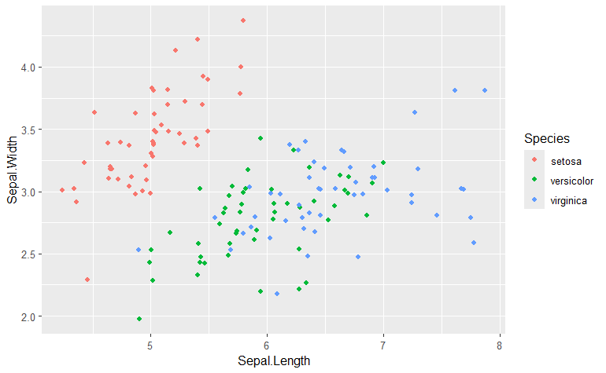

```r
posn_j <- position_jitter(0.1)

ggplot(iris, aes(x = Sepal.Length,
                 y = Sepal.Width,
                 col = Species)) +
  geom_point(position = posn_j)
```

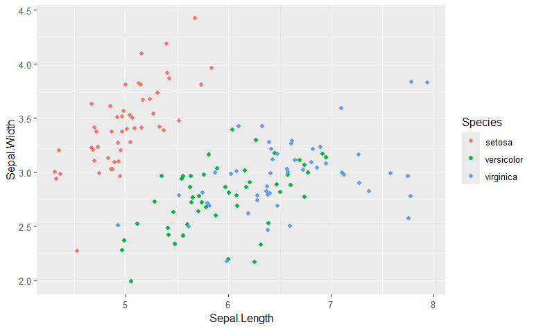

```r
posn_j <- position_jitter(0.1,
                          seed = 136)

ggplot(iris, aes(x = Sepal.Length,
                 y = Sepal.Width,
                 col = Species)) +
  geom_point(position = posn_j)
```

- Set arguments for the position
- Consistency across plots & layers

### Scale functions

- `scale_x_*()`, e.g. `scale_x_continuous()`
- `scale_y_*()`
- `scale_color_*()`, e.g. `scale_color_discrete()`
- `scale_fill_*()`
- `scale_shape_*()`
- `scale_linetype_*()`
- `scale_size_*()`

### `scale_*_*()`

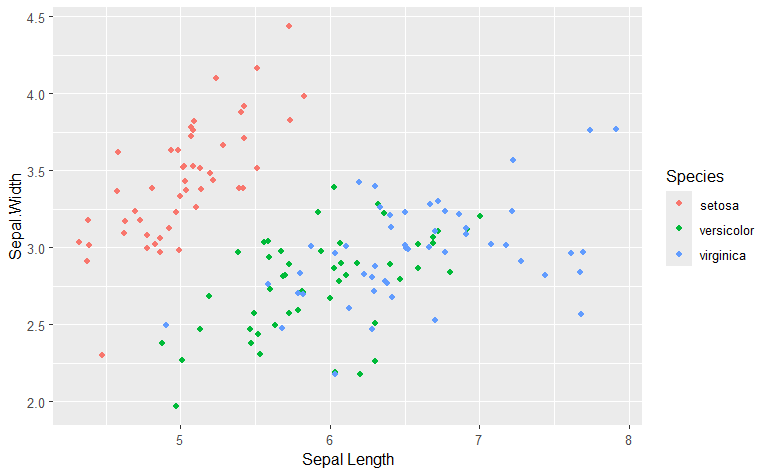

```r
ggplot(iris, aes(x = Sepal.Length,
                 y = Sepal.Width,
                 color = Species)) +
  geom_point(position = "jitter") +
  scale_x_continuous("Sepal Length") +
  scale_color_discrete("Species")
```

### The limits argument

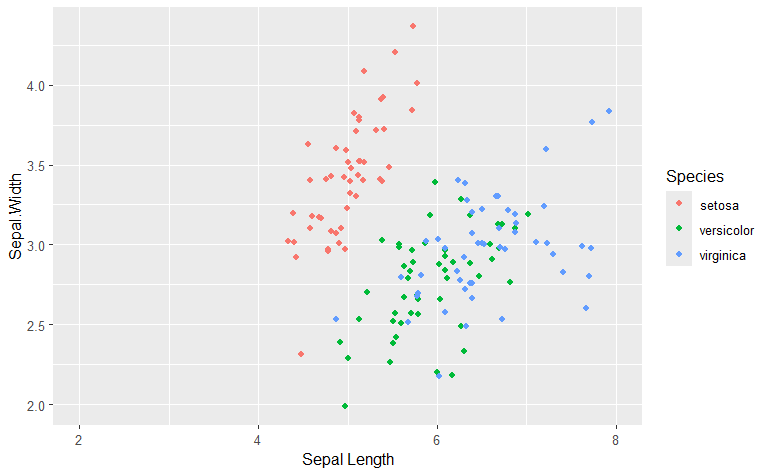

```r
ggplot(iris, aes(x = Sepal.Length,
                 y = Sepal.Width,
                 color = Species)) +
  geom_point(position = "jitter") +
  scale_x_continuous("Sepal Length",
                     limits = c(2, 8)) +
  scale_color_discrete("Species")
```

### The breaks argument

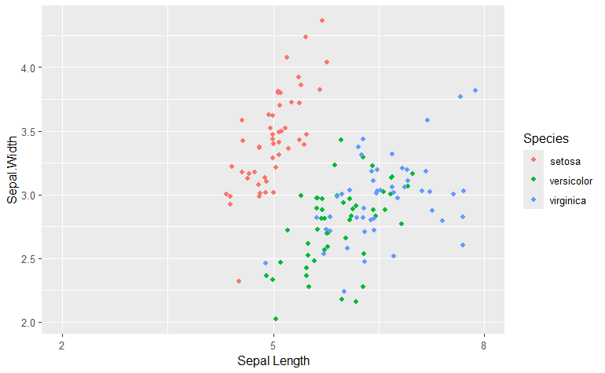

```r
ggplot(iris, aes(x = Sepal.Length,
                 y = Sepal.Width,
                 color = Species)) +
  geom_point(position = "jitter") +
  scale_x_continuous("Sepal Length",
                     limits = c(2, 8),
                     breaks = seq(2, 8, 3)) +
  scale_color_discrete("Species")
```

### The expand argument

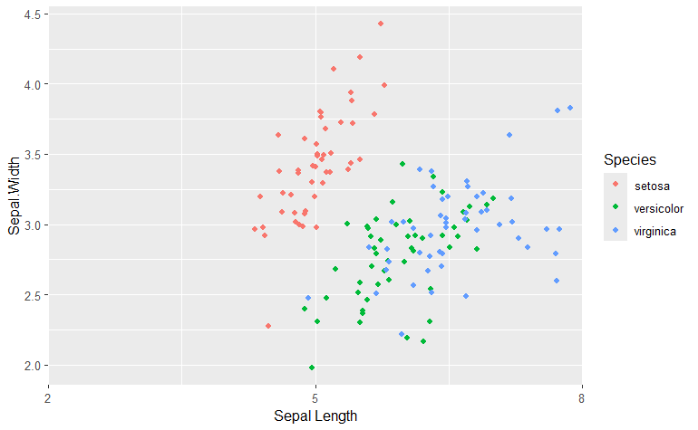

```r
ggplot(iris, aes(x = Sepal.Length,
                 y = Sepal.Width,
                 color = Species)) +
  geom_point(position = "jitter") +
  scale_x_continuous("Sepal Length",
                     limits = c(2, 8),
                     breaks = seq(2, 8, 3),
                     expand = c(0, 0)) +
  scale_color_discrete("Species")
```

### The labels argument

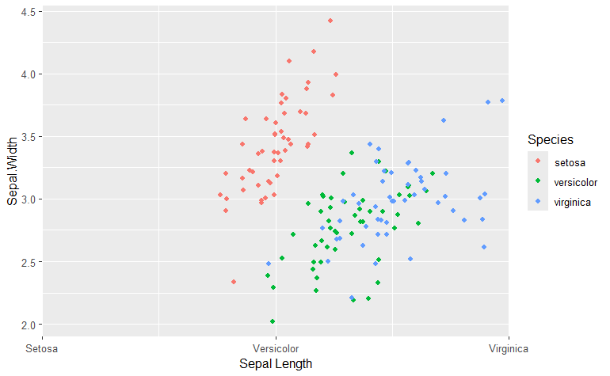

```r
ggplot(iris, aes(x = Sepal.Length,
                 y = Sepal.Width,
                 color = Species)) +
  geom_point(position = "jitter") +
  scale_x_continuous("Sepal Length",
                     limits = c(2, 8),
                     breaks = seq(2, 8, 3),
                     expand = c(0, 0),
                     labels = c("Setosa",
                                "Versicolor",
                                "Virginica")) +
  scale_color_discrete("Species")
```

### `labs()`

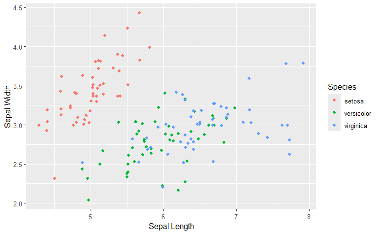

```r
ggplot(iris, aes(x = Sepal.Length,
                 y = Sepal.Width,
                 color = Species)) +
  geom_point(position = "jitter") +
  labs(x = "Sepal Length",
       y = "Sepal Width",
       color = "Species")
```

## Video 2.4: Aesthetics Best Practices

### Which aesthetics?

- Use your creative know-how, and
- Follow some clear guidelines
- Jacques Bertin’s Semiology of Graphics, 1967
- William Cleveland’s Visualizing Data, 1993
- William Cleveland’s The Elements of Graphing Data, 1985

### Form follows function

- Primary function: accurate and efficient representations
- Secondary: visually appealing, beautiful plots
- Guiding principles:
  - Never:
    - Misrepresent or obscure data
    - Confuse viewers with complexity
  - Always:
    - Consider the audience and the purpose of every plot

### best choices for aesthetics

- Efficient: provides a faster overview than numeric summaries
- Accurate: minimizes information loss

### Aesthetics - continuous variables

```r
ggplot(iris, aes(x = Sepal.Length,
                 y = Sepal.Width,
                 color = Species)) +
  geom_point()
```

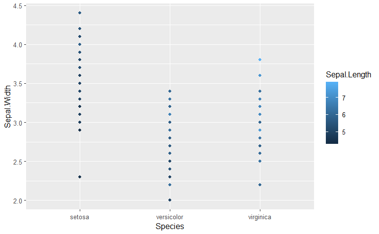

```r
ggplot(iris, aes(color = Sepal.Length,
                 y = Sepal.Width,
                 x = Species)) +
  geom_point()
```

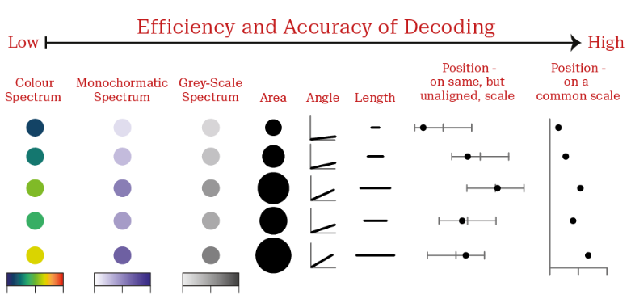

Efficiency and Accuracy of Decoding

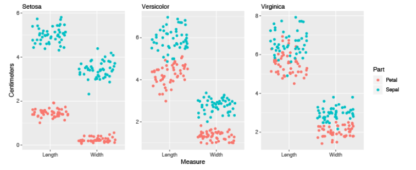

Three iris scatter plots

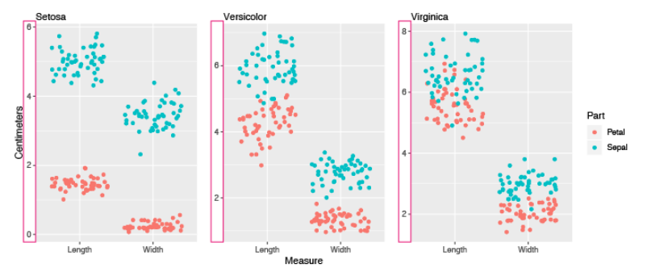

Three iris scatter plots, unaligned y axes

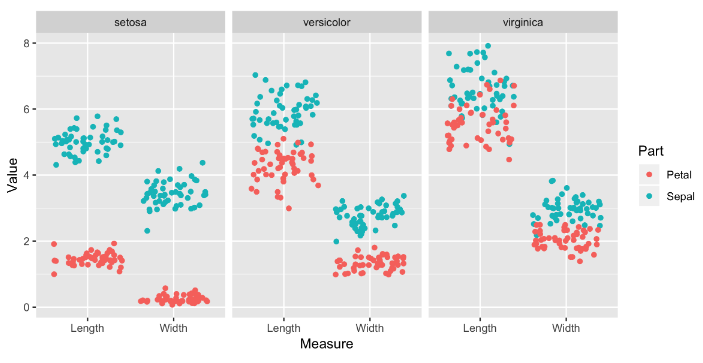

Single faceted plot, common y-axis

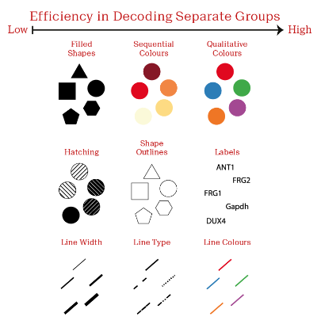

Efficiency in decoding separate groups

### Aesthetics - categorical variables

```r
ggplot(iris, aes(x = Sepal.Length,
                 y = Sepal.Width,
                 col = Species)) +
  geom_point()
```

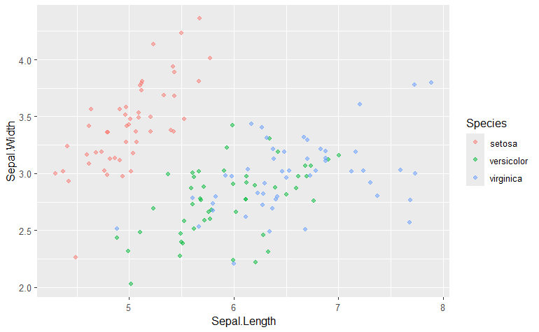

```r
ggplot(iris, aes(x = Sepal.Length,
                 y = Sepal.Width,
                 col = Species)) +
  geom_point(position = "jitter",
             alpha = 0.5)
```

# Chapter 3: Geometries

## Video 3.1: Scatter plots

### 48 geometries

```markdown
| geom_*     |            |            |            |            |            |            |
|------------|------------|------------|------------|------------|------------|------------|
| abline     | contour    | dotplot    | jitter     | pointrange | ribbon     | spoke      |
| area       | count      | errorbar   | label      | polygon    | rug        | step       |
| bar        | crossbar   | errorbarh  | line       | qq         | segment    | text       |
| bin2d      | curve      | freqpoly   | linerange  | qq_line    | sf         | tile       |
| blank      | density    | hex        | map        | quantile   | sf_label   | violin     |
| boxplot    | density2d  | histogram  | path       | raster     | sf_text    | vline      |
| col        | density_2d | hline      | point      | rect       | smooth     |            |
```

### Common plot types

```markdown
| Plot type | Possible Geoms |
| --- | --- |
| scatter plots | points, jitter, abline, smooth, count |
```

### Scatter plots

- Each geom can accept specific aesthetic mappings, e.g. geom_point():

```markdown
| Essential |
| --- |
| x, y |
```

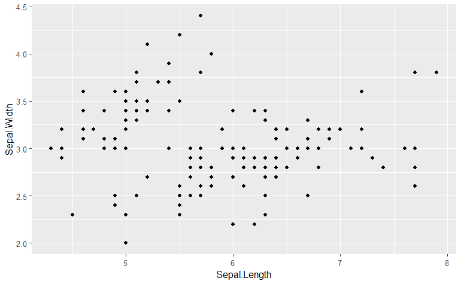

```r
ggplot(iris, aes(x = Sepal.Length,
                 y = Sepal.Width)) +
  geom_point()
```

```markdown
| Essential | Optional |
| --- | --- |
| x, y | alpha, color, fill, shape, size, stroke |
```

```r
ggplot(iris, aes(x = Sepal.Length,
                 y = Sepal.Width,
                 col = Species)) +
  geom_point()
```

### Geom-specific aesthetic mappings

```r
# These result in the same plot!
ggplot(iris, aes(x = Sepal.Length,
                 y = Sepal.Width,
                 col = Species)) +
  geom_point()
```

```r
ggplot(iris, aes(x = Sepal.Length,
                 y = Sepal.Width)) +
  geom_point(aes(col = Species))
```

- Control aesthetic mappings of each layer independently.

```r
head(iris, 3)
```

|  | Sepal.Length | Sepal.Width | Petal.Length | Petal.Width | Species |
| --- | --- | --- | --- | --- | --- |
| 1 | 5.1 | 3.5 | 1.4 | 0.2 | setosa |
| 2 | 4.9 | 3.0 | 1.4 | 0.2 | setosa |
| 3 | 4.7 | 3.2 | 1.3 | 0.2 | setosa |

```r
library(dplyr)
iris %>%
  group_by(Species) %>%
  summarise_all(mean) -> iris.summary

iris.summary # Summary statistics
```

| Species | Sepal.Length | Sepal.Width | Petal.Length | Petal.Width |
| --- | --- | --- | --- | --- |
| setosa | 5.006 | 3.428 | 1.462 | 0.246 |
| versicolor | 5.936 | 2.770 | 4.260 | 1.326 |
| virginica | 6.588 | 2.974 | 5.552 | 2.026 |

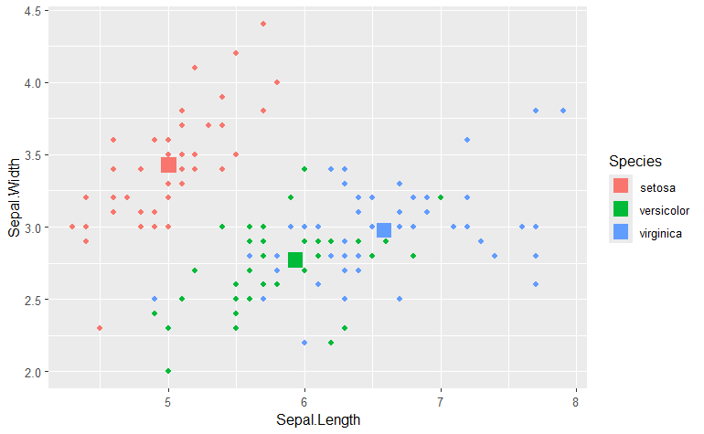

```r
ggplot(iris, aes(x = Sepal.Length, y = Sepal.Width, col = Species)) +
  # Inherits both data and aes from ggplot()
  geom_point() +
  # Different data, but inherited aes
  geom_point(data = iris.summary, shape = 15, size = 5)
```

### Shape attribute values

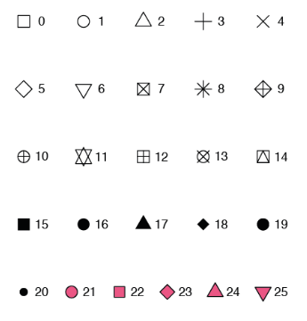

Shape attribute values

### Example

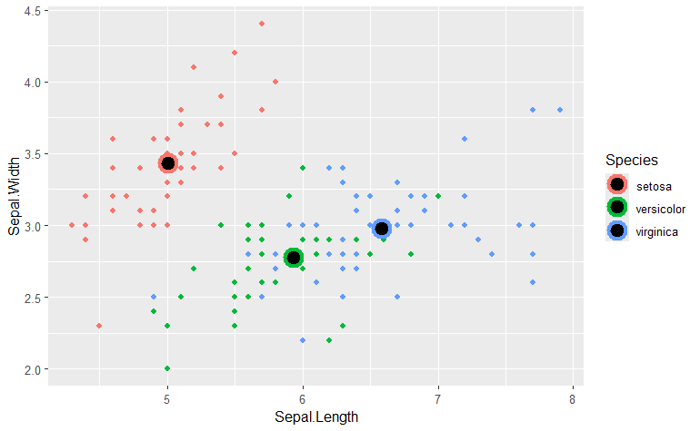

```r
ggplot(iris, aes(x = Sepal.Length, y = Sepal.Width, col = Species)) +
  geom_point() +
  geom_point(data = iris.summary, shape = 21, size = 5,
             fill = "black", stroke = 2)
```

### On the fly stats by ggplot2

- See the second course for the stats layer.
- Note: avoid plotting only the mean without a measure of spread, e.g. standard deviation

### `position = "jitter"`

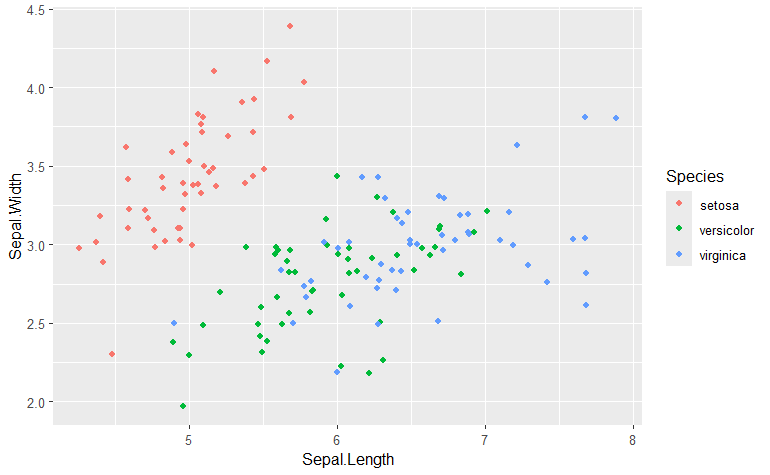

```r
ggplot(iris, aes(x = Sepal.Length,
                 y = Sepal.Width,
                 col = Species)) +
  geom_point(position = "jitter")
```

### `geom_jitter()`

A shortcut to `geom_point(position = “jitter”)

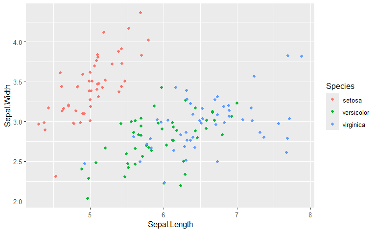

```r
ggplot(iris, aes(x = Sepal.Length,
                 y = Sepal.Width,
                 col = Species)) +
  geom_jitter()
```

### Don’t forget to adjust alpha

- Combine jittering with alpha blending if necessary

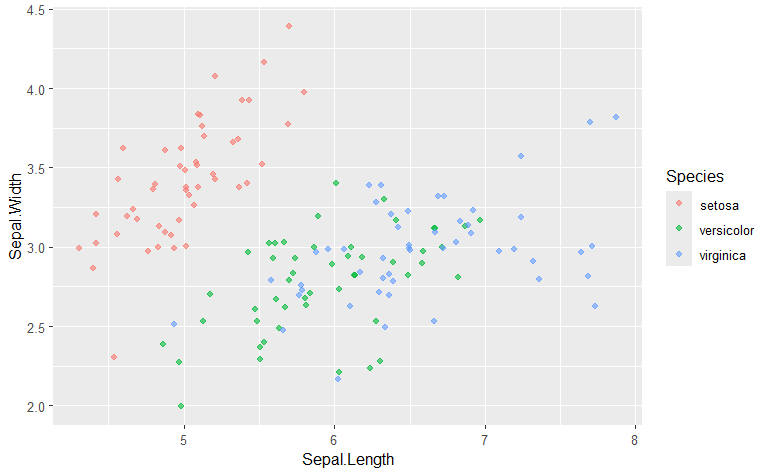

```r
ggplot(iris, aes(x = Sepal.Length,
                 y = Sepal.Width,
                 col = Species)) +
  geom_jitter(alpha = 0.6)
```

### Hollow circles also help

- `shape = 1` is a hollow circle
- Not necessary to also use alpha blending.

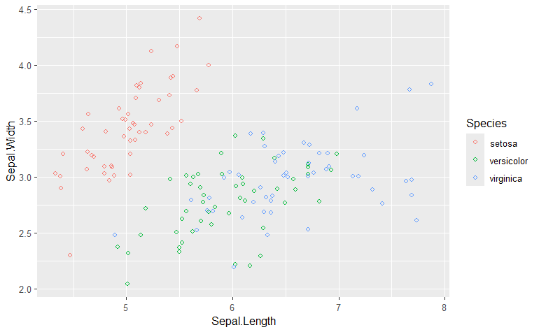

```r
ggplot(iris, aes(x = Sepal.Length,
                 y = Sepal.Width,
                 col = Species)) +
  geom_jitter(shape = 1)
```

## Video 3.2: Histograms

### Common plot types

```markdown
| Plot type | Possible Geoms |
| --- | --- |
| scatter plots | points, jitter, abline, smooth, count |
| **Bar plots** | **histogram, bar, col, errorbar** |
| Line plots | line, path |
```

### Histograms

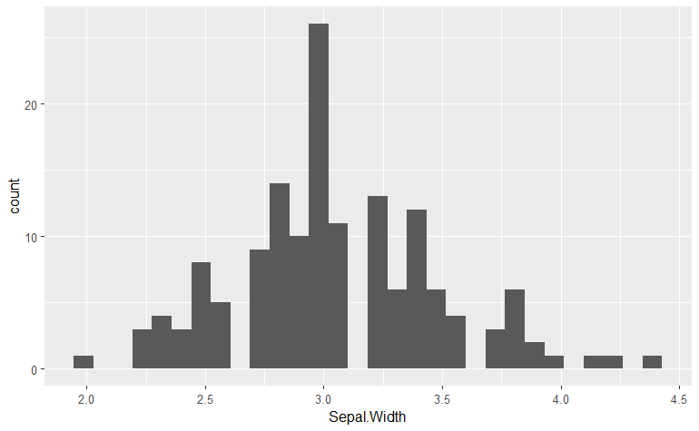

```r
ggplot(iris, aes(x = Sepal.Width)) +
  geom_histogram()
```

- A plot of binned values, ie a statistical function.

```markdown
`stat_bin()` using `bins = 30`.
Pick better value with `binwidth`.
```

### Default of 30 even bins

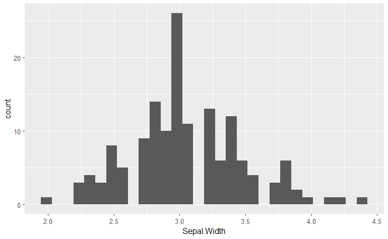

```r
ggplot(iris, aes(x = Sepal.Width)) +
  geom_histogram()
```

```r
# Default bin width:
diff(range(iris$Sepal.Width)) / 30
```

```
[1] 0.08
```

### Intuitive and meaningful bin widths

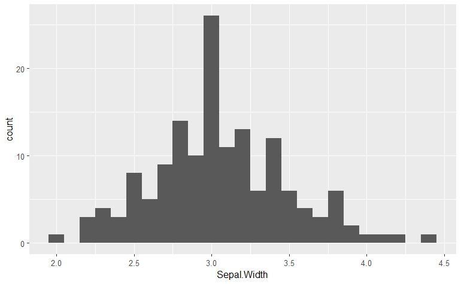

```r
ggplot(iris, aes(x = Sepal.Width)) +
  geom_histogram(binwidth = 0.1)
```

```r
# Always set meaningful bin widths for your data.
# No spaces between bars.
```

### Reposition tick marks

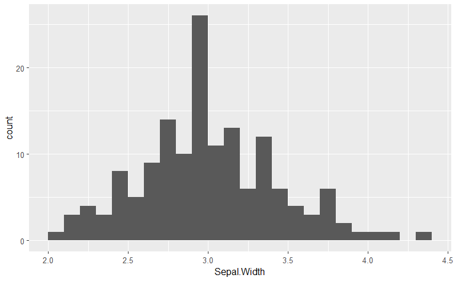

```r
ggplot(iris, aes(x = Sepal.Width)) +
  geom_histogram(binwidth = 0.1,
                 center = 0.05)
```

```r
# Always set meaningful bin widths for your data.
# No spaces between bars.
# X axis labels are between bars
```

### Different species

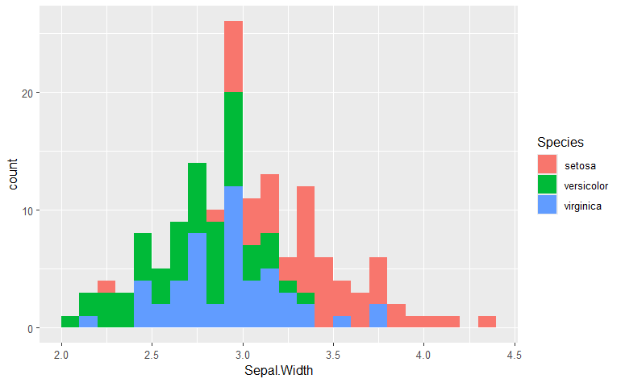

```r
ggplot(iris, aes(x = Sepal.Width,
                 fill = Species)) +
  geom_histogram(binwidth = .1,
                 center = 0.05)
```

### Default position is “stack”

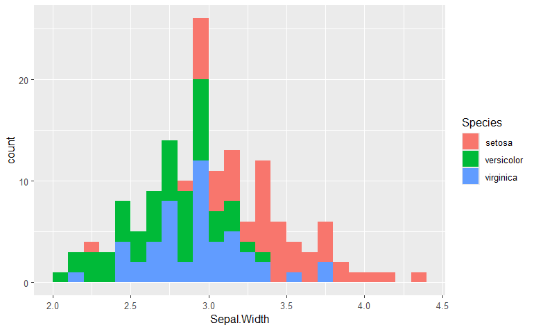

```r
ggplot(iris, aes(x = Sepal.Width,
                 fill = Species)) +
  geom_histogram(binwidth = .1,
                 center = 0.05,
                 position = "stack")
```

### position = “dodge”

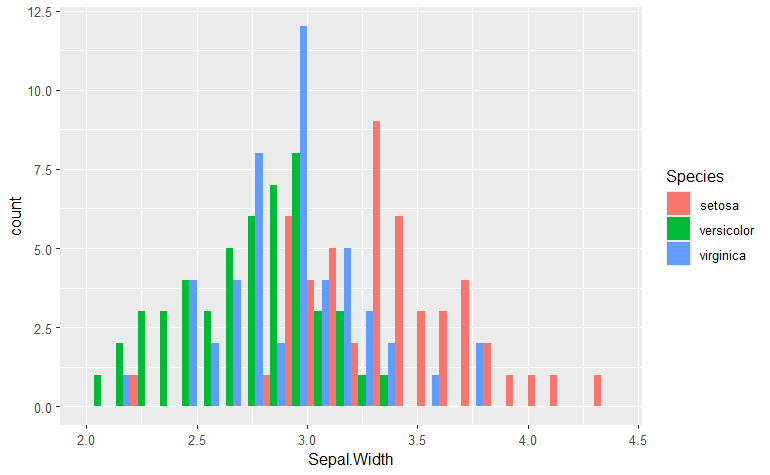

```r
ggplot(iris, aes(x = Sepal.Width,
                 fill = Species)) +
  geom_histogram(binwidth = .1,
                 center = 0.05,
                 position = "dodge")
```

### position = “fill”

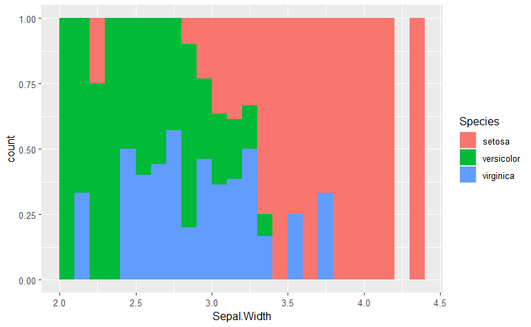

```r
ggplot(iris, aes(x = Sepal.Width,
                 fill = Species)) +
  geom_histogram(binwidth = .1,
                 center = 0.05,
                 position = "fill")
```

## Video 3.3: Bar Plots

### Bar plots, with a categorical X-axis

- Use `geom_bar()` or `geom_col()`

| Geom | Stat | Action |
| --- | --- | --- |
| `geom_bar()` | “count” | counts the number of cases at each x position |
| `geom_col()` | “identity” | plot actual values |

- All positions from before are available
- Two types:
  - Absolute counts
  - Distributions

### Habits of mammals

```r
str(msleep)
```

```
tibble [83 × 11] (S3: tbl_df/tbl/data.frame)
 $ name        : chr [1:83] "Cheetah" "Owl monkey" "Mountain beaver" "Greater short-tailed shrew" ...
 $ genus       : chr [1:83] "Acinonyx" "Aotus" "Aplodontia" "Blarina" ...
 $ vore        : chr [1:83] "carni" "omni" "herbi" "omni" ...
 $ order       : chr [1:83] "Carnivora" "Primates" "Rodentia" "Soricomorpha" ...
 $ conservation: chr [1:83] "lc" NA "nt" "lc" ...
 $ sleep_total : num [1:83] 12.1 17 14.4 14.9 4 14.4 8.7 7 10.1 3 ...
 $ sleep_rem   : num [1:83] NA 1.8 2.4 2.3 0.7 2.2 1.4 NA 2.9 NA ...
 $ sleep_cycle : num [1:83] NA NA NA 0.133 0.667 ...
 $ awake       : num [1:83] 11.9 7 9.6 9.1 20 9.6 15.3 17 13.9 21 ...
 $ brainwt     : num [1:83] NA 0.0155 NA 0.00029 0.423 NA NA NA 0.07 0.0982 ...
 $ bodywt      : num [1:83] 50 0.48 1.35 0.019 600 ...
```

### Bar plot

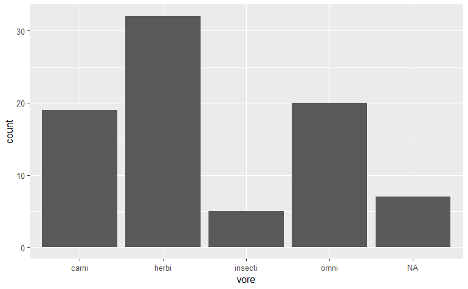

```r
ggplot(msleep, aes(x = vore)) +
  geom_bar()
```

### Plotting distributions instead of absolute counts

```r
library(tidyr)
# Calculate Descriptive Statistics:
iris %>%
  select(Species, Sepal.Width) %>%
  gather(key, value, -Species) %>%
  group_by(Species) %>%
  summarise(avg = mean(value),
            stdev = sd(value)) -> iris_summ_long

iris_summ_long
```

| Species | avg | stdev |
| --- | --- | --- |
| setosa | 3.428 | 0.3790644 |
| versicolor | 2.770 | 0.3137983 |
| virginica | 2.974 | 0.3224966 |

### Plotting distributions

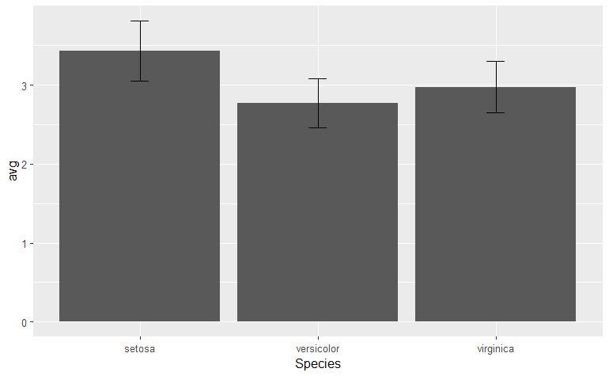

```r
ggplot(iris_summ_long, aes(x = Species,
                           y = avg)) +
  geom_col() +
  geom_errorbar(aes(ymin = avg - stdev,
                    ymax = avg + stdev),
                width = 0.1)
```

## Video 3.4: Line Plots

```r
library(beaver)
str(beaver2)
```

```
'data.frame':   100 obs. of  4 variables:
 $ day  : num  307 307 307 307 307 307 307 307 307 307 ...
 $ time : num  930 940 950 1000 1010 1020 1030 1040 1050 1100 ...
 $ temp : num  36.6 36.7 36.9 37.1 37.2 ...
 $ activ: num  0 0 0 0 0 0 0 0 0 0 ...
```

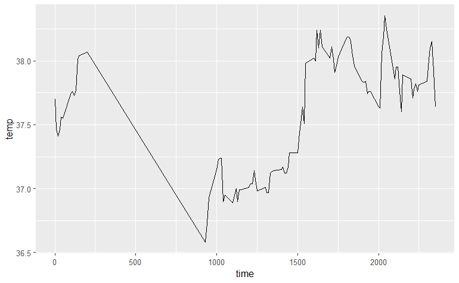

```r
ggplot(beaver2, aes(x = time, y = temp)) +
  geom_line()
```

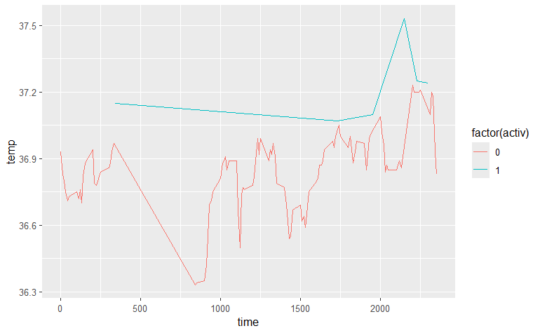

```r
ggplot(beaver1, aes(x = time,
                    y = temp,
                    color = factor(activ))
                    ) +
  geom_line()
```

### The fish catch dataset

```r
fish <- fish.tidy
str(fish)
```

```
'data.frame':   427 obs. of  3 variables:
 $ Species: Factor w/ 7 levels "Pink","Chum",..: 1 1 1 1 1 1 1 1 1 1 ...
 $ Year   : int  1950 1951 1952 1953 1954 1955 1956 1957 1958 1959 ...
 $ Capture: int  100600 259000 132600 235900 123400 244400 203400 270119 200798 200085 ...
```

### Linetype aesthetic

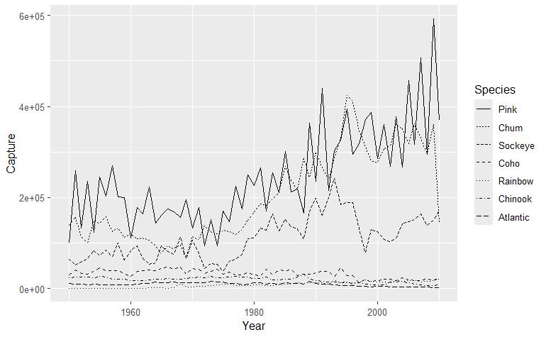

```r
ggplot(fish, aes(x = Year,
                 y = Capture,
                 linetype = Species)) +
  geom_line()
```

### Size aesthetic

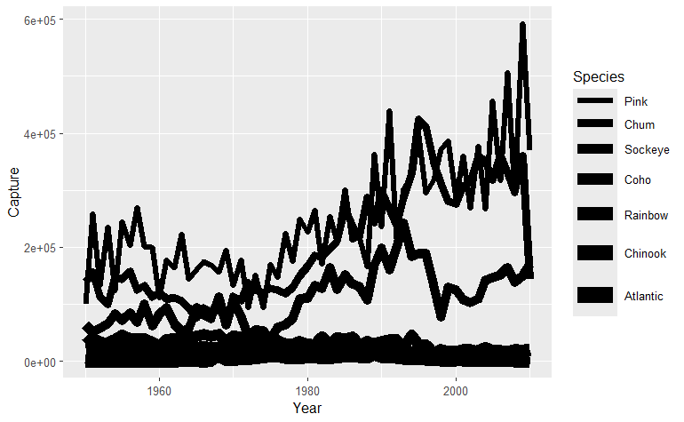

```r
ggplot(fish, aes(x = Year,
                 y = Capture,
                 size = Species)) +
  geom_line()
```

### Color aesthetic

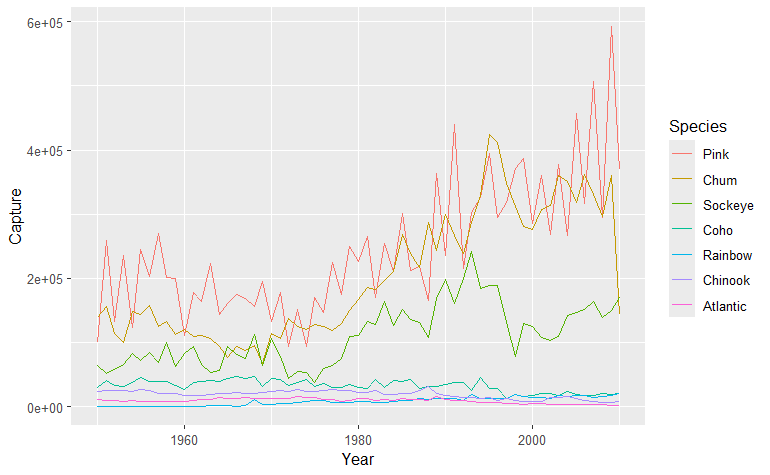

```r
ggplot(fish, aes(x = Year,
                 y = Capture,
                 color = Species)) +
  geom_line()
```

### Fill aesthetic with `geom_area()`

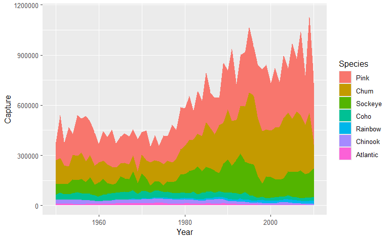

```r
ggplot(fish, aes(x = Year,
                 y = Capture,
                 fill = Species)) +
  geom_area()
```

### Using position = “fill”

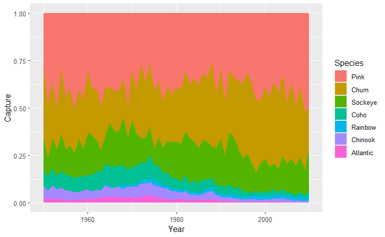

```r
ggplot(fish, aes(x = Year,
                 y = Capture,
                 fill = Species)) +
  geom_area(position = "fill")
```

### `geom_ribbon()`

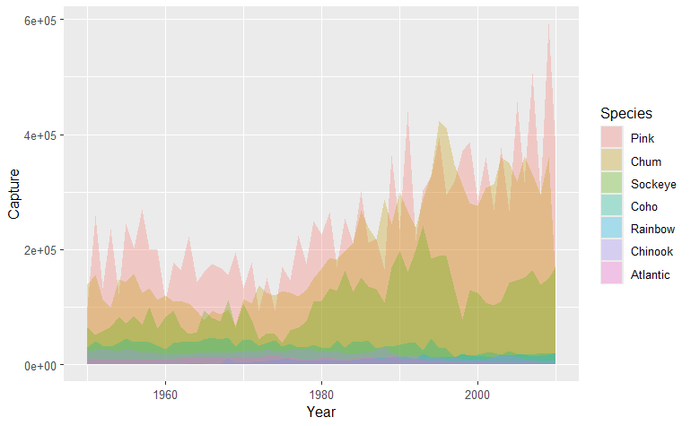

```r
ggplot(fish, aes(x = Year,
                 y = Capture,
                 fill = Species)) +
  geom_ribbon(aes(ymax = Capture,
                  ymin = 0),
              alpha = 0.3)
```

# Chapter 4: Themes

## Video 4.1: Themes from scratch

### The themes layer

- All non-data ink
- Visual elements not part of the data
- Three types:

```markdown
| type | modified using|
| --- | --- |
| text | element_text() |
| line | element_line() |
| rect | element_rect() |
```

### A starting plot…

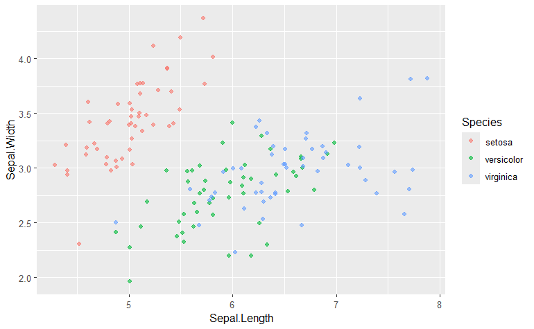

```r
ggplot(iris, aes(x = Sepal.Length, y = Sepal.Width, color = Species)) +
  geom_jitter(alpha = 0.6)
```

### The text elements

```markdown
theme(
text
  axis.title
    axis.title.x
      axis.title.x.top
      axis.title.x.bottom
    axis.title.y
      axis.title.y.left
      axis.title.y.right   t
  title
    legend.title
    plot.title
    plot.subtitle
    plot.caption
    plot.tag
  axis.text
    axis.text.x
      axis.text.x.top
      axis.text.x.bottom
    axis.text.y
      axis.text.y.left
      axis.text.y.right
  legend.text
  strip.text
    strip.text.x
    strip.text.y)
```

### Adjusting theme elements

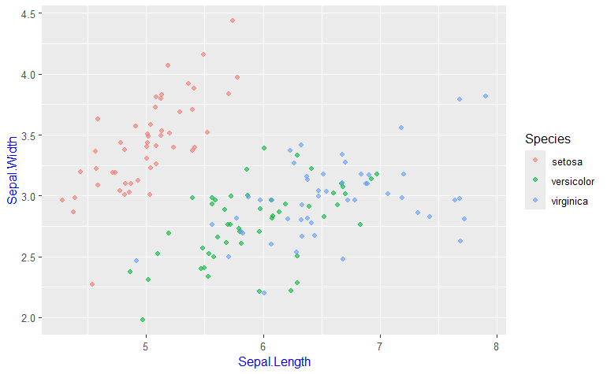

```r
ggplot(iris, aes(x = Sepal.Length,
                 y = Sepal.Width,
                 color = Species)) +
  geom_jitter(alpha = 0.6) +
  theme(axis.title = element_text(color = "blue"))
```

### A starting plot…

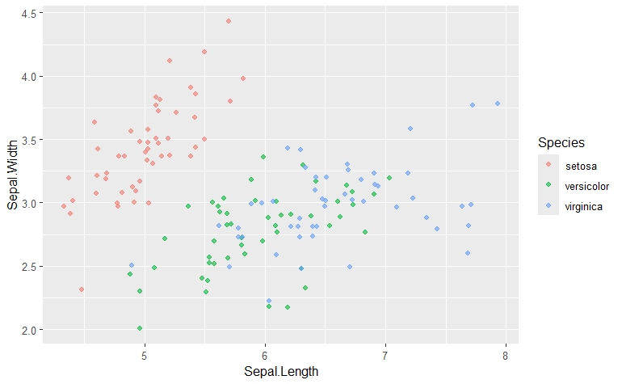

```r
ggplot(iris, aes(x = Sepal.Length, y = Sepal.Width, color = Species)) +
  geom_jitter(alpha = 0.6)
```

### Line elements

```markdown
theme(
line,
  axis.ticks,
    axis.ticks.x,
      axis.ticks.x.top,
      axis.ticks.x.bottom,
    axis.ticks.y,
      axis.ticks.y.left,
      axis.ticks.y.right,
    axis.line,
      axis.line.x,
        axis.line.x.top,
        axis.line.x.bottom,
      axis.line.y,
        axis.line.y.left,
        axis.line.y.right,
  panel.grid,
    panel.grid.major,
      panel.grid.major.x,
      panel.grid.major.y,
    panel.grid.minor,
      panel.grid.minor.x,
      panel.grid.minor.y)
```

### A starting plot

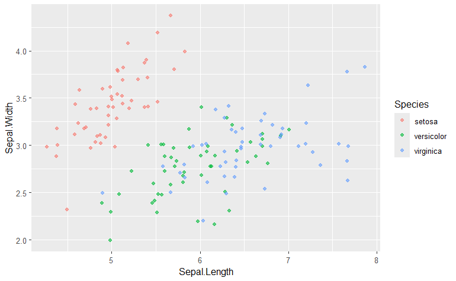

```r
ggplot(iris, aes(x = Sepal.Length, y = Sepal.Width, color = Species)) +
  geom_jitter(alpha = 0.6)
```

### Rect elements

```markdown
theme(
rect,
  legend.background,
  legend.key,
  legend.box.background,
  panel.background,
  panel.border,
  plot.background,
  strip.background,
    strip.background.x,
    strip.background.y)
```

### Hierarchical naming reflects inheritance rules

e.g. text:

```markdown
text
  axis.title
    axis.title.x
      axis.title.x.top
      axis.title.x.bottom
    axis.title.y
      axis.title.y.left
      axis.title.y.right
```

e.g. Lines

```markdown
line
  axis.ticks
    axis.ticks.x
      axis.ticks.x.top
      axis.ticks.x.bottom
    axis.ticks.y
      axis.ticks.y.left,
      axis.ticks.y.right
    axis.line
      axis.line.x
        axis.line.x.top
        axis.line.x.bottom
      axis.line.y
        axis.line.y.left
        axis.line.y.right
```

### `element_blank()`

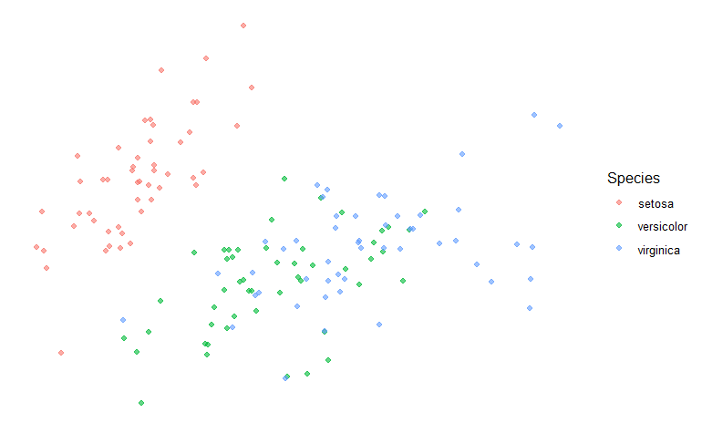

```r
ggplot(iris, aes(x = Sepal.Length,
                 y = Sepal.Width,
                 color = Species)) +
  geom_jitter(alpha = 0.6) +
  theme(line = element_blank(),
        rect = element_blank(),
        text = element_blank())
```

## Video 4.2: Theme flexibility

### Ways to use themes

1. From scratch (last video)
2. **Theme layer object**
3. Built-in themes
   - `ggplot2` or `ggthemes` packages
4. Built-in themes from other packages
5. Update/Set default theme

### Defining theme objects

- Useful when you have many plots.
- Provides consistency in style
- Apply a specific theme everywhere

```r
z <- ggplot(iris, aes(x = Sepal.Length, y = Sepal.Width, color = Species)) +
  geom_jitter(alpha = 0.6) +
  scale_x_continuous("Sepal Length (cm)", limits = c(4,8), expand = c(0,0)) +
  scale_y_continuous("Sepal Width (cm)", limits = c(1.5,5), expand = c(0,0)) +
  scale_color_brewer("Species", palette = "Dark2", labels = c("Setosa", "Versicolor", "Virginica"))
```

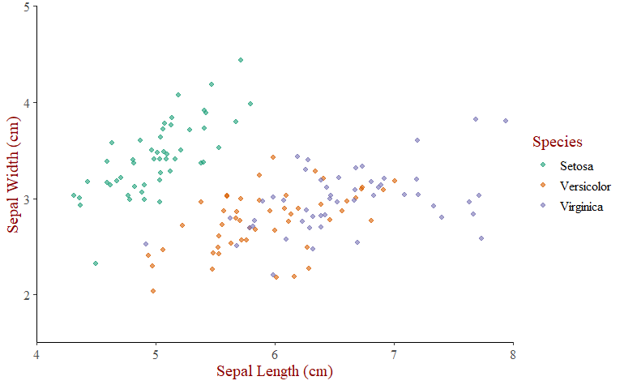

```r
z + theme(text = element_text(family = "serif", size = 14),
          rect = element_blank(),
          panel.grid = element_blank(),
          title = element_text(color = "#8b0000"),
          axis.line = element_line(color = "black"))
```

```r
theme_iris <- theme(text = element_text(family = "serif", size = 14),
                    rect = element_blank(),
                    panel.grid = element_blank(),
                    title = element_text(color = "#8b0000"),
                    axis.line = element_line(color = "black"))
```

### Reusing theme objects

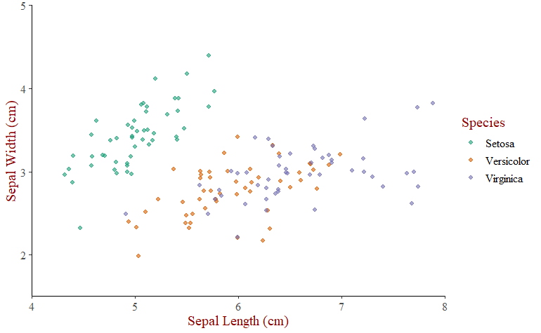

```r
z + theme_iris
```

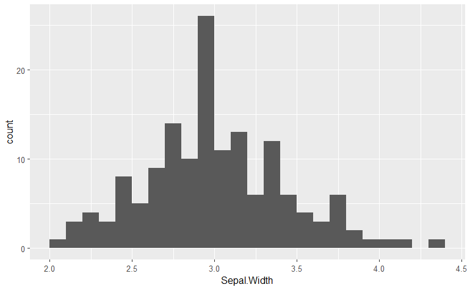

```r
m <- ggplot(iris, aes(x = Sepal.Width)) +
  geom_histogram(binwidth = 0.1,
                 center = 0.05)
m
```

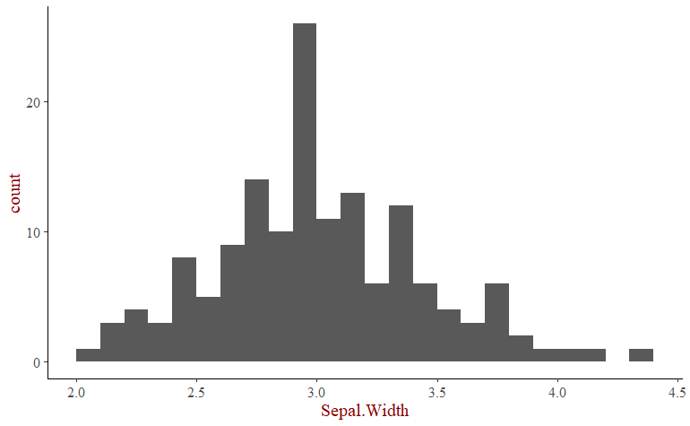

```r
m + theme_iris
```

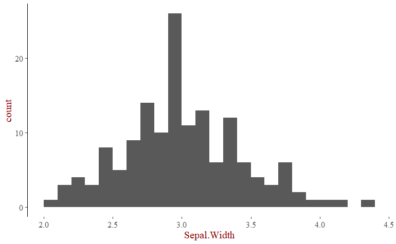

```r
m +
  theme_iris +
  theme(axis.line.x = element_blank())
```